# Exactly How Good of a Player is Steph Curry?

By: Anant Patel

#### Prelude:

Pronunced by many players and analysts as the greatest shooter of all time, Stephen Curry is a professional basketball player who currently plays on the Golden State Warriors. Drafted in 2009 in the first round, Curry has been an astonishing player ever since he stepped foot on an NBA court. It is said by many that he changed the game of basketball, given his ability to consistently make shots from almost anywhere on the court. His accomplishments are many, but his most striking one is unanimously winning the Most Valuable Player (MVP) in the years 2015-2016. My goal is to do some metrics to see how much he has improved since he was a rookie, as well as compare him to NBA league averages to get a grasp of his shooting level.

## Part 1: Data Collection/Curation

```python
import pandas as pd
import matplotlib.pyplot as plt
import numpy as np
from datetime import datetime
```

```python
stats = pd.read_excel("steph_curry_stats.xlsx") # reading data from excel file at https://data.world/datatouille/stephen-curry-stats
```

```python
stats.head()
```

|  | Dates | Opponent | Score | Minutes | Successful Shots | Total Shots | 3 Points Succesful | Total 3 Points | Successful FT | Total FT | ... | AST | BLK | STL | PF | TO | PTS | Type | Result | Score GS | Score Opponent |
| --- | --- | --- | --- | --- | --- | --- | --- | --- | --- | --- | --- | --- | --- | --- | --- | --- | --- | --- | --- | --- | --- |
| 0 | 2009-10-28 | HOU | L 107-108 | 36 | 7 | 12 | 0 | 1 | 0 | 0 | ... | 7 | 0 | 4 | 2 | 2 | 14 | REGULAR SEASON STATS | L | 107 | 108 |
| 1 | 2009-10-30 | PHX | L 101-123 | 39 | 5 | 9 | 2 | 3 | 0 | 0 | ... | 4 | 0 | 1 | 5 | 3 | 12 | REGULAR SEASON STATS | L | 101 | 123 |
| 2 | 2009-11-04 | MEM | W 113-105 | 28 | 3 | 6 | 1 | 2 | 0 | 0 | ... | 9 | 0 | 2 | 4 | 1 | 7 | REGULAR SEASON STATS | W | 113 | 105 |
| 3 | 2009-11-06 | LAC | L 90-118 | 22 | 1 | 5 | 0 | 1 | 3 | 4 | ... | 3 | 0 | 0 | 6 | 0 | 5 | REGULAR SEASON STATS | L | 90 | 118 |
| 4 | 2009-11-08 | SAC | L 107-120 | 31 | 4 | 8 | 1 | 2 | 0 | 2 | ... | 6 | 0 | 0 | 4 | 5 | 9 | REGULAR SEASON STATS | L | 107 | 120 |

5 rows × 21 columns

The data from the table above was obtained from https://data.world/datatouille/stephen-curry-stats thanks to Tristian Malherbe. It includes a multitude of stats from every game Curry played from his 2009 rookie year to 2018. This data set does not contain statistics from the past 3 years, which is key missing information to take note of. Now, we will proceed to clean our data table by removing columns we dont need for our analysis.

## Part 2: Data Management/Representation

```python
stats = stats.drop(columns=['Minutes', 'Opponent', 'Score', 'Type', 'Result', 'Score GS', 'Score Opponent']) # dropping unneeded columns
```

I have decided to drop the columns that do not directly deal with Curry's individual statistics, such as winning/losing, which opponent he played, etc. My goal is to analyze Curry's stats over each year, so I will convert the Dates column to a Years column, only recording the year in which each game occurred.

```python
years = []
for index, row in stats.iterrows():
    y = row['Dates'].date().year # extracting only the year of a date
    years.append(y)

stats = stats.assign(Dates=years) # replacing the Date's YYYY-MM-DD format to only YYYY
```

Now, we want to include an additional stat that is not in our current dataset, called 'Efficiency'. Efficiency in basketball is a measure of an individual player's efficiency in a game. It was created by statistician Martin Manley, and is derived from the equation shown in the code below. A more comprehensive metric for calculating efficiency is called the player efficiency rating (PER), but the calculations are too complex, and we would need more data in order to compute it. More information can be found at https://en.wikipedia.org/wiki/Efficiency_(basketball)#:~:text=Individual%20player%20efficiency%20is%20expressed,Missed%20FT%20%2D%20TO)%20%2F%20GP.

```python
# Adding the efficiency column to Steph Curry's stats
# Efficiency formula: (PTS + REB + AST + STL + BLK − Missed FG − Missed FT - TO) / GP

efficiencyArr = []
for index, row in stats.iterrows():
    pts = row['PTS']
    reb = row['REB']
    ast = row['AST']
    stl = row['STL']
    blk = row['BLK']
    missed_fg = row['Total Shots'] - row['Successful Shots']
    missed_ft = row['Total FT'] - row['Successful FT']
    to = row['TO']
    efficiency = pts + reb + ast + stl + blk - missed_fg - missed_ft - to
    efficiencyArr.append(efficiency)

stats['Efficiency'] = efficiencyArr
```

Now, our data is cleaned up and ready to be represented.

```python
stats.head()
```

|  | Dates | Successful Shots | Total Shots | 3 Points Succesful | Total 3 Points | Successful FT | Total FT | REB | AST | BLK | STL | PF | TO | PTS | Efficiency |
| --- | --- | --- | --- | --- | --- | --- | --- | --- | --- | --- | --- | --- | --- | --- | --- |
| 0 | 2009 | 7 | 12 | 0 | 1 | 0 | 0 | 2 | 7 | 0 | 4 | 2 | 2 | 14 | 20 |
| 1 | 2009 | 5 | 9 | 2 | 3 | 0 | 0 | 2 | 4 | 0 | 1 | 5 | 3 | 12 | 12 |
| 2 | 2009 | 3 | 6 | 1 | 2 | 0 | 0 | 5 | 9 | 0 | 2 | 4 | 1 | 7 | 19 |
| 3 | 2009 | 1 | 5 | 0 | 1 | 3 | 4 | 1 | 3 | 0 | 0 | 6 | 0 | 5 | 4 |
| 4 | 2009 | 4 | 8 | 1 | 2 | 0 | 2 | 4 | 6 | 0 | 0 | 4 | 5 | 9 | 8 |

## Part 3: Exploratory Data Analysis

Using the matplotlib library, we will make three plots that show Curry's statistics over time. We will plot Curry's points per game, successful three point shots, and efficiency from 2009-2018. A three point shot in basketball is a shot that is made from beyond that three point arch on a basketball court. More information about three pointers can be found here https://www.rookieroad.com/basketball/shot-types/3-pointer/. Our main intention is see if we can find a trend in his stats over the years.

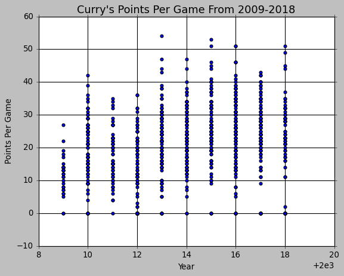

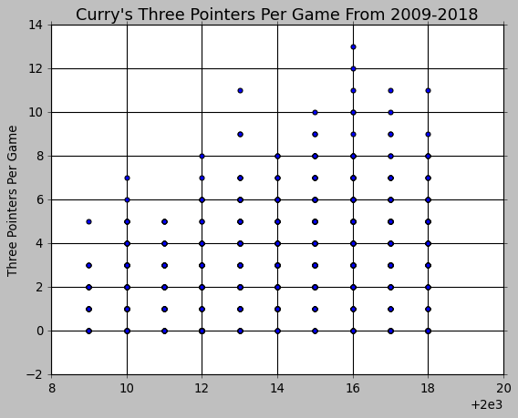

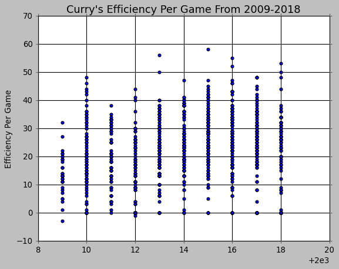

```python
# Plotting points per game across time using the matplotlib library
# labelling/styling the graph
plt.style.use('grayscale')
plt.xlabel("Year")
plt.ylabel("Points Per Game")
plt.title("Curry's Points Per Game From 2009-2018")
years_x = stats['Dates']
points = stats['PTS']
plt.scatter(years_x, points) # Plotting data using a scatter plot
plt.show()

# Plotting three pointers per game across time using the matplotlib library
plt.ylabel("Three Pointers Per Game")
plt.title("Curry's Three Pointers Per Game From 2009-2018")
three_pointers = stats['3 Points Succesful']
plt.scatter(years_x, three_pointers) # Plotting data using a scatter plot
plt.show()

# Plotting efficiency per game across time using the matplotlib library
plt.ylabel("Efficiency Per Game")
plt.title("Curry's Efficiency Per Game From 2009-2018")
points = stats['Efficiency']
plt.scatter(years_x, points) # Plotting data using a scatter plot
plt.show()
```

Now that we have our plots ready, we can try to make some observations and possible hypotheses about the data. Firstly, we can clearly see that Curry made significant improvement in his play from his 2009 rookie season to his second year. There is an evident large jump in his point per game (PPG), 3 pointers made, and efficiency after his first season. Additionally, we can see that his statistics mainly increase every year until his historic 2016 MVP season, but still remain ridulously high in years 2017 and 2018.

A hypothesis that we can look to test is to see if Curry's progression follows a linear pattern. From an initial observation it seems as if Curry's progression is not truly linear. Lets use three regression models, one for each graph above, and see if we accept or reject the null hypothesis of no linear relationships between Stephen Curry's statistics over time.

## Part 4: Hypothesis Testing

We must first import two key modules that will allow us to create and assess our three regression models. The sklearn module will give us our regression model, and the statsmodel lets us view all of the important statistics regarding the models.

```python
from sklearn.linear_model import LinearRegression
import statsmodels.api as sm
```

```python
# This function will print the statistics of a linear regression given the x and y values
def showRegressionResults(x, y):
    X2 = sm.add_constant(x)
    est = sm.OLS(y, X2)
    est2 = est.fit()
    print(est2.summary())


x = stats['Dates'].to_numpy().reshape(-1, 1) # reshaping the series for the model
y = stats['PTS']
model = LinearRegression()
model.fit(x,y) # Fitting regression model for points per game across time
showRegressionResults(x, y) # Printing the results of the regression
```

```
                            OLS Regression Results
==============================================================================
Dep. Variable:                    PTS   R-squared:                       0.049
Model:                            OLS   Adj. R-squared:                  0.048
Method:                 Least Squares   F-statistic:                     44.89
Date:                Mon, 17 May 2021   Prob (F-statistic):           3.73e-11
Time:                        18:09:58   Log-Likelihood:                -3388.2
No. Observations:                 878   AIC:                             6780.
Df Residuals:                     876   BIC:                             6790.
Df Model:                           1
Covariance Type:            nonrobust
==============================================================================
                 coef    std err          t      P>|t|      [0.025      0.975]
------------------------------------------------------------------------------
const      -1997.5084    301.178     -6.632      0.000   -2588.622   -1406.394
x1             1.0019      0.150      6.700      0.000       0.708       1.295
==============================================================================
Omnibus:                        8.979   Durbin-Watson:                   1.193
Prob(Omnibus):                  0.011   Jarque-Bera (JB):                8.941
Skew:                          -0.225   Prob(JB):                       0.0114
Kurtosis:                       2.794   Cond. No.                     1.56e+06
==============================================================================

Notes:
[1] Standard Errors assume that the covariance matrix of the errors is correctly specified.
[2] The condition number is large, 1.56e+06. This might indicate that there are
strong multicollinearity or other numerical problems.
```

By analysing the results from our regression above, we see that the p-value we got for points per game across time is 3.73e-11. This value is much less than 0.05, so our data is statistically significant and we should reject the null hypothesis of no linear relationship between the year and Curry's points per game. Now, lets analyze the relationship between Curry's 3 pointers per game over time.

```python
y = stats['3 Points Succesful']
model = LinearRegression()
model.fit(x,y) # Fitting regression model for three pointers per game across time
showRegressionResults(x, y)
```

```
                            OLS Regression Results
==============================================================================
Dep. Variable:     3 Points Succesful   R-squared:                       0.089
Model:                            OLS   Adj. R-squared:                  0.088
Method:                 Least Squares   F-statistic:                     85.81
Date:                Mon, 17 May 2021   Prob (F-statistic):           1.50e-19
Time:                        18:09:58   Log-Likelihood:                -1973.0
No. Observations:                 878   AIC:                             3950.
Df Residuals:                     876   BIC:                             3960.
Df Model:                           1
Covariance Type:            nonrobust
==============================================================================
                 coef    std err          t      P>|t|      [0.025      0.975]
------------------------------------------------------------------------------
const       -553.5693     60.091     -9.212      0.000    -671.508    -435.630
x1             0.2764      0.030      9.263      0.000       0.218       0.335
==============================================================================
Omnibus:                       42.225   Durbin-Watson:                   1.472
Prob(Omnibus):                  0.000   Jarque-Bera (JB):               47.269
Skew:                           0.539   Prob(JB):                     5.44e-11
Kurtosis:                       3.360   Cond. No.                     1.56e+06
==============================================================================

Notes:
[1] Standard Errors assume that the covariance matrix of the errors is correctly specified.
[2] The condition number is large, 1.56e+06. This might indicate that there are
strong multicollinearity or other numerical problems.
```

Similar to our previous analysis, the p-value we obtained for Curry's three pointers per game across time is 1.50e-19, which is much lower than the cutoff for significance at 0.05. This means that we should reject the null hypothesis of no linear relationship between the year and Steph's number of three pointers per game. Finally, lets get the results for Curry's efficiency over time.

```python
y = stats['Efficiency']
model = LinearRegression()
model.fit(x,y) # Fitting regression model for efficiency per game across time
showRegressionResults(x, y)
```

```
                            OLS Regression Results
==============================================================================
Dep. Variable:             Efficiency   R-squared:                       0.034
Model:                            OLS   Adj. R-squared:                  0.033
Method:                 Least Squares   F-statistic:                     31.01
Date:                Mon, 17 May 2021   Prob (F-statistic):           3.41e-08
Time:                        18:09:59   Log-Likelihood:                -3464.1
No. Observations:                 878   AIC:                             6932.
Df Residuals:                     876   BIC:                             6942.
Df Model:                           1
Covariance Type:            nonrobust
==============================================================================
                 coef    std err          t      P>|t|      [0.025      0.975]
------------------------------------------------------------------------------
const      -1807.9030    328.394     -5.505      0.000   -2452.433   -1163.373
x1             0.9080      0.163      5.569      0.000       0.588       1.228
==============================================================================
Omnibus:                       16.081   Durbin-Watson:                   1.355
Prob(Omnibus):                  0.000   Jarque-Bera (JB):               10.287
Skew:                          -0.112   Prob(JB):                      0.00584
Kurtosis:                       2.520   Cond. No.                     1.56e+06
==============================================================================

Notes:
[1] Standard Errors assume that the covariance matrix of the errors is correctly specified.
[2] The condition number is large, 1.56e+06. This might indicate that there are
strong multicollinearity or other numerical problems.
```

Our p-value is 3.41e-08, so the null hypothesis is once again rejected of no linear relationship between the year and Steph's efficiency per game. As a result of this analysis, I can conclude that my earlier hypothesis of Curry not having a linear relationship among his three major stats can be falsified. This means that Curry has been steadily becoming a better player from 2009-2018. Now, lets include some statistics to show how Curry changed the league since he entered in 2009.

My plan is to plot Curry's average three point percentage and average three points attempted per year against the league averages, using two different graphs. I chose to include three point percentage because I want to show how efficient Curry is in his three point shot compared to the rest of the league. The reason I chose to include three points attempted per game is to visualize the impact that Curry had on the league, and why people say he changed the game forever. After viewing these two plots, we should be able to visually see the difference that Curry made on the rest of the NBA.

```python
years = [2000, 2001, 2002, 2003, 2004, 2005, 2006, 2007, 2008, 2009, 2010, 2011, 2012, 2013, 2014, 2015, 2016, 2017, 2018]
y = years[9:19]
y
```

```
[2009, 2010, 2011, 2012, 2013, 2014, 2015, 2016, 2017, 2018]
```

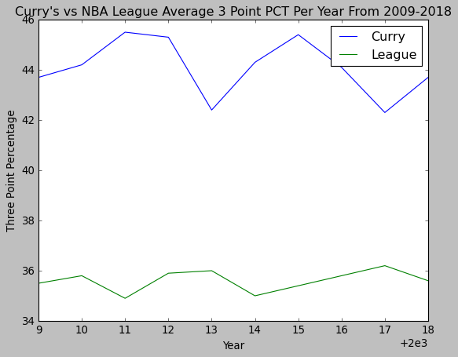

```python
# For the sake of convenience, data for Curry's 3 point percentage and the league average stats are manually entered
# Curry's stats per year are gathered from https://www.basketball-reference.com/players/c/curryst01.html
# The league average stats per year are found at https://public.tableau.com/profile/scot1745#!/vizhome/NBAHistoricalLeagueAverages/Story1

years = [2000, 2001, 2002, 2003, 2004, 2005, 2006, 2007, 2008, 2009, 2010, 2011, 2012, 2013, 2014, 2015, 2016, 2017, 2018] # starting from year 2000 to visualize a trend
since_2009 = years[9:19] # x values for Stephen Curry's plots

curry_3pct = [43.7, 44.2, 45.5, 45.3, 42.4, 44.3, 45.4, 44.1, 42.3, 43.7] # 3 point percentages
curry_3PA = [4.8, 4.6, 4.7, 7.7, 7.9, 8.1, 11.2, 10.0, 9.8, 11.7] # 3 points attempted

league_3pct = [35.5, 35.8, 34.9, 35.9, 36.0, 35.0, 35.4, 35.8, 36.2, 35.6]
league_3PA = [13.7, 14.7, 14.7, 14.9, 15.8, 16.0, 16.9, 18.1, 18.1, 18.1, 18.0, 18.4, 20.0, 21.5, 22.4, 24.1, 27.0, 29.0, 32.0]

# Plotting three point percentages using Matplotlib
plt.style.use('classic')
plt.xlabel("Year")
plt.ylabel("Three Point Percentage")
plt.title("Curry's vs NBA League Average 3 Point PCT Per Year From 2009-2018")
plt.plot(since_2009, curry_3pct)
plt.plot(since_2009, league_3pct)
plt.legend(['Curry', 'League'])
plt.show()
```

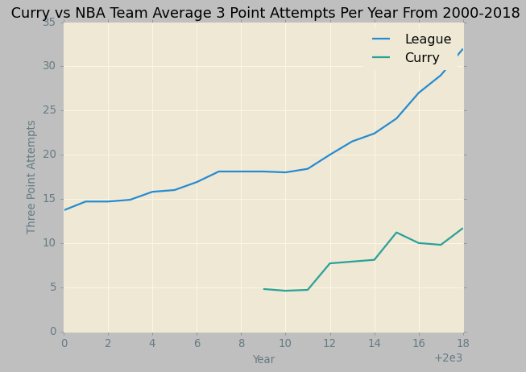

```python
# Plotting average three point attempts per year using Matplotlib
plt.clf() # clearing the previous plot
plt.style.use('Solarize_Light2')
plt.xlabel("Year")
plt.ylabel("Three Point Attempts")
plt.title(" Curry vs NBA Team Average 3 Point Attempts Per Year From 2000-2018")
plt.plot(years, league_3PA)
plt.plot(since_2009, curry_3PA)
plt.legend(['League', 'Curry'])
plt.show()
```

Looking at the first plot from above, we can see that Curry's three pointer efficiency is much above the league average. His ability to make the three pointer from deep beyond the three point line is what makes him such a lethal player. By analyzing the second graph, we can get a very noteworthy observation: ever since Stephen Curry entered the league in 2009, the average number of three point shots attempted per team has been increasing at a fast rate. From 2009 to 2018, the avg number of 3 point shots taken by teams increased from 18.1 to 32.0 per game. Now, we definetely cannot conclude casuality from this, but this can lead to a more extensive investigation on Stephen Curry's impact on the league's three point shooting.

## Part 5: Insights Attained

There are a few takeaways that we can gather from this analysis on Steph Curry as a player. We can see that Curry has definitely improved over his years in the NBA, and that his progression follows a linear growth. We can also takeaway the fact that Curry is much more efficient at shooting three pointers than the rest of the league. Finally, we have a reason to further investigate Curry's impact on the entire league's willingness to shoot more three pointers. All in all, we can conclude that Stephen Curry is an elite player who continues to dominate whenever hes on the court, and will leave an impact on the NBA even after he retires.